# TUG: The Battle for Field Position

Brian Bak and Jackson Thomas

# Introduction

In today’s game, there is a lack of existing metrics that evaluate the performance of special teams players. The majority of statistics that exist are ones that measure the outcome of the play result, and rarely the quality of a play. Specifically within punting, there are an abundance of variables outside of the punter’s control that influence the outcome of a punt, which leads to an inconsistent telling of how well a punt was executed, and the overall ability of a punter. Football is complicated battle full of decisions regarding field position. If we think of the field position battle as a game of tug and war, we recognize that the punt team wishes to minimize their opponent’s field position after the end of each punt, while the return team wishes to maximize their own field position after the end of each punt. As a result, we created a metric concept called TUG for punters and returners.

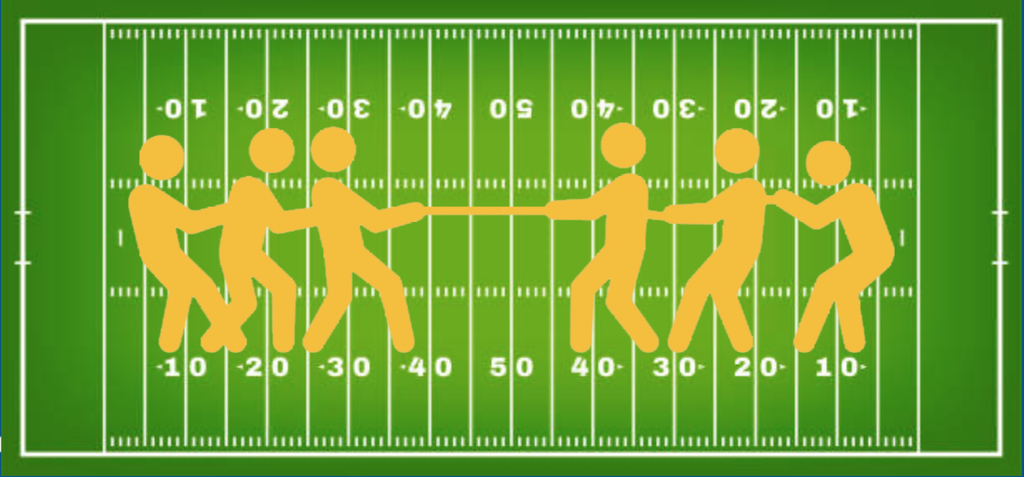

# What is TUG?

Our TUG metric evaluates and scores the quality of a punt/return based on how well the punter/returner achieves field position given their starting territory. TUGp is specifically for punters and TUGr is specifically for returners.

- **TUGp**
  - *TUGp = puntingTeamTerritory + kickLength*
  - puntingTeamTerritory: The total number of yards behind the line of scrimmage.
  - kickLength: The total number of yards the punt traveled in the air.
- **TUGr**
  - *TUGr = returningTeamTerritory + kickReturnYardage*
  - returningTeamTerritory = (100 - TUGp)
  - kickReturnYardage: The number of return yards the returner gains.

### Why is TUG Practical?

The metrics are all on a scale of 0-100. The score is absolute as it takes into account different situations. For example, a 60 yard punt on the 30 yard line is different than a 60 yard punt on the opponent’s 45 yard line. Regardless, the goal of each punt play remains the same in any scenario: minimize field position for the returner if you are punting, and maximize field position if you are returning.

### The Purpose of TUG

The purpose of this statistic is to evaluate a punter’s true ability to consistently pin their opponent given different field position scenarios. On the contrary, we use this to evaluate how well a returner can optimize a return for their team. This takes into account specifically the events that a punter has control over as it eliminates all outside variables that occur within a punt return. A great punt can no longer be negated due to a missed tackle.

# What Influences TUG?

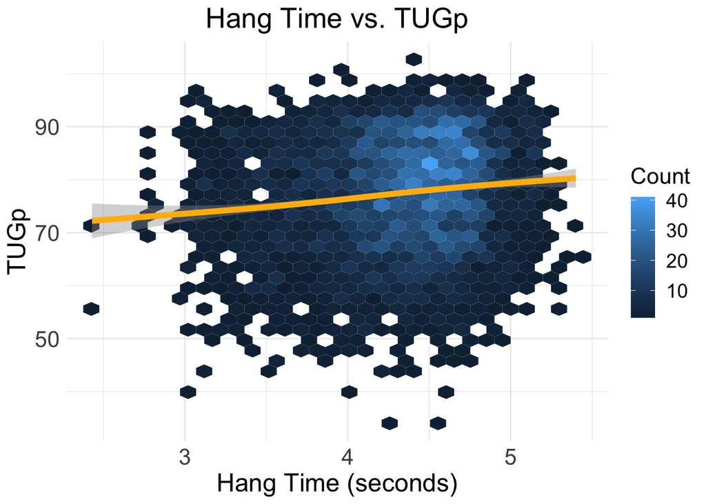

The plot above displays the relationship between hang time and TUGp. We can infer that there is a trend that as hang time increases, TUGp increases.

[figure not shown]

The chart displays how different types of punts impact TUGp. One strategy we can recommend to gain a higher TUG is to perform an Aussie style punt. We cannot conclude that Rugby style punts lead to the lowest average TUGp score due to the variability in sample size and because it is a newly implemented kick style.

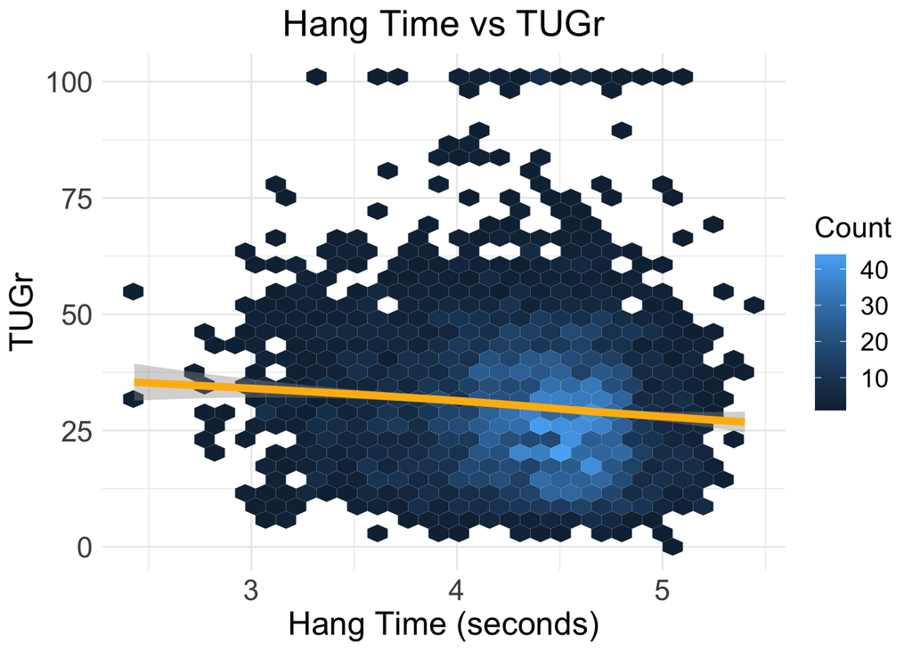

The plot above displays the relationship between hang time and TUGr. We can infer that there is a trend that as hang time increases, TUGr decreases. This makes sense because as the ball is in the air for a longer period of time, the punting team has a greater opportunity to track down the returner and minimize the return.

[figure not shown]

The chart displays how different types of return outcomes impact TUGr. From a punter’s perspective, we can conclude that the optimal decision is to execute a punt that leads to a fair catch.

# Player Analysis

[output not shown]

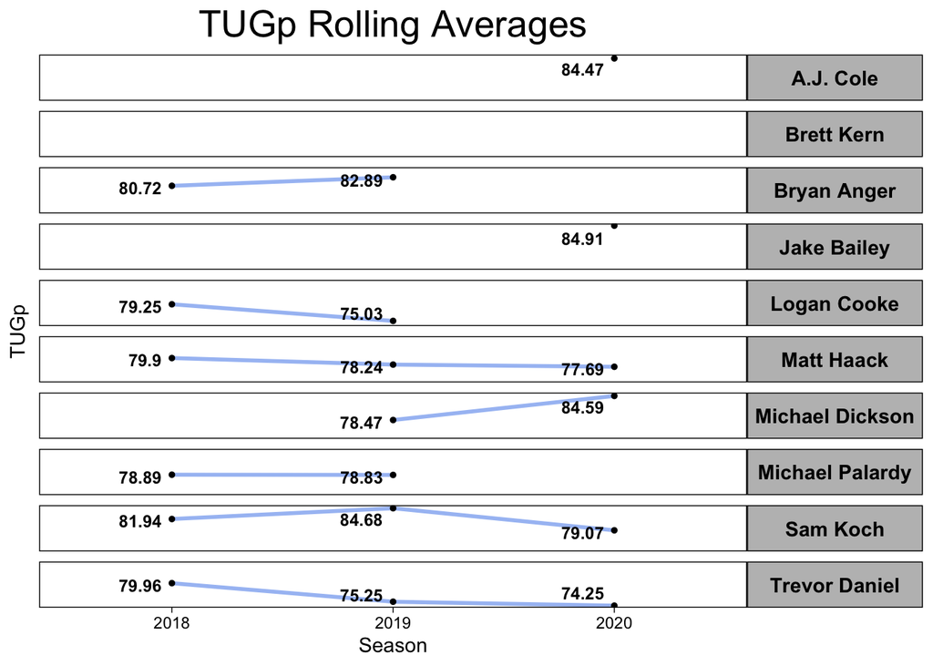

[output not shown]

[output cut: 27 more lines]

[output not shown]

[output cut: 67 more lines]

We additionally applied this to see which returners performed well and consistently scored high TUGr scores. Based on the our criteria of a minimum of 16 returns, we can observe that from the seasons of 2018-2020, Deonte Harris has the highest average TUGr score. This suggests that Harris frequently gave his team a more optimal field position for his team than any other returner. Additionally, we applied TUG+ to returners as well. For example, Deonte Harris’ TUG+ score of 132 shows that he is 32% better at TUGr than the average returner, given that a TUG+ score of 100 is average. On the contrary, Darrius Shepard’s TUG+ score of 72 indicates that he is 28% worse at TUGr than the average returner.

### Top Ten Tug Scores

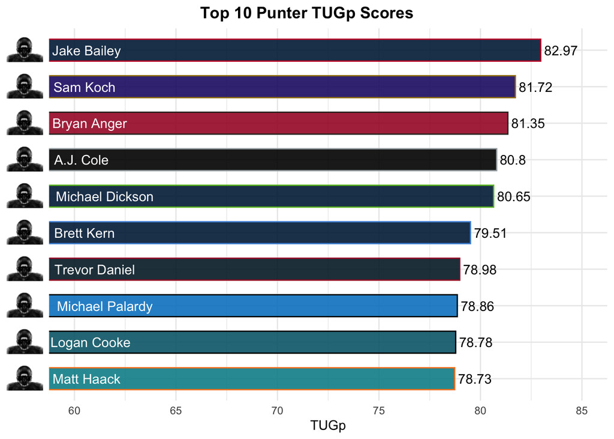

Top Ten Punters with their Corresponding TUGp Scores

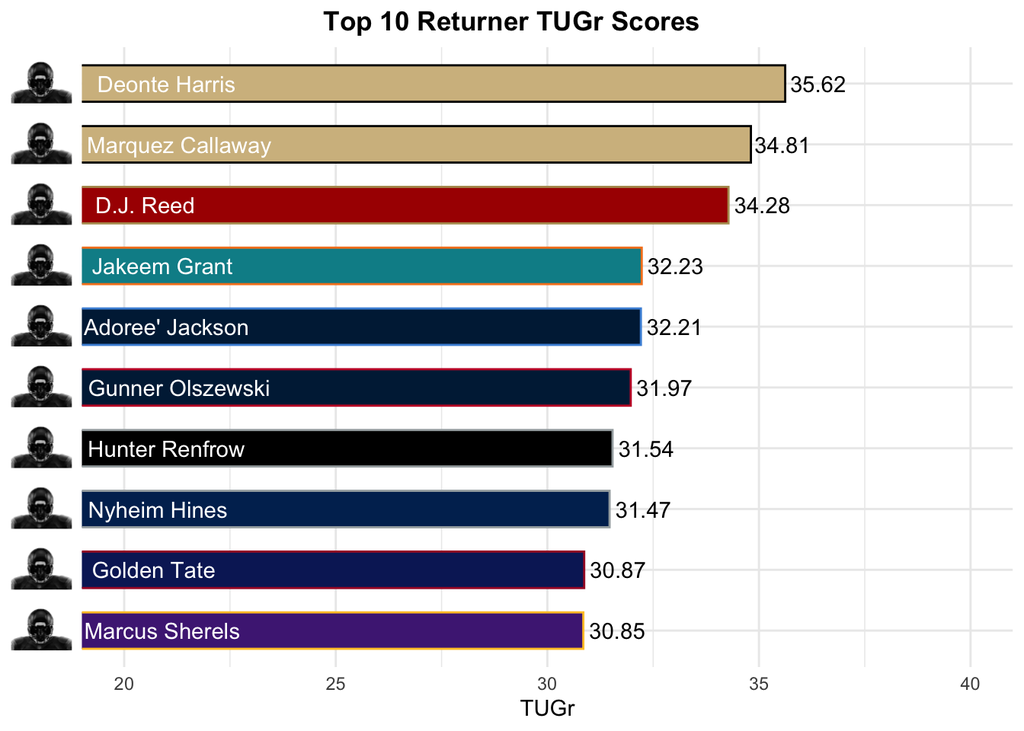

Top Ten Returners with their Corresponding TUGr Scores.

### Closing Analysis:

Our goal was to create a metric that was simple, practical, and unique. We hope that the creation of TUG allows for better evaluation on identifying and distinguishing special teams’ skill from one another. Thank you for reading.

#### Twitter:

#### Jackson Thomas | @baseballbyJT